# HW6

Manipulating 20 Years of Natural Gas Data

TLamkin  
2022-03-23

## INTRODUCTION

This homework demonstrates the tidy-ing and manipulation of 20 years of natural gas production and price data using a variety of packages including:

- STRINGR
- TIDYVERSE
- DPLYR
- GGPLOT2
- MATRIXSTATS

The goal of this analysis was to: - Examine the fluctuation in natural gas prices over the course of the average year and how that fluctuation varies between commercial and residential uses.  
- Determine if there exists a relationship between the monthly domestic gas production and the price.

## Checking the Environment

I like to verify that my working directory and library paths are the same and that I have the correct packages installed.

```r
# Verify library path

.libPaths()
```

```
[1] "C:/Users/theresa/Documents/R/win-library/4.1"
[2] "C:/Program Files/R/R-4.1.2/library"
```

```r
# set the working directory to be the same as the library path

setwd("C:/Users/theresa/Documents/R/win-library/4.1")

# verify the working directory

getwd()
```

```
[1] "C:/Users/theresa/Documents/R/win-library/4.1"
```

```r
# Installing Tidyverse and readxl packages with explicitly defining the URL of where it lives. This is to get around a Mirror error.  The packages are now already installed and therefore commented out for efficiency.  However, should this be run in a new environment, these should be re-installed.

# install.packages("tidyverse", repos = "http://cran.us.r-project.org")
# install.packages("readxl", repos = "http://cran.us.r-project.org")

# load the necessary libraries for the processing
# install.packages("matrixStats", repos = "http://cran.us.r-project.org")
library(tidyverse)
library(dplyr)
library(readxl)
library(readr)
library(stringr)
library(ggplot2)
library(quantreg)
library(lubridate)
library(matrixStats)
```

## Loading the Data

There are 2 datasets containing US natural gas data as provided by the U.S. Energy Information Administration (http://www.eia.gov/oil_gas/natural_gas/data_publications/natural_gas_monthly/ngm.html).

Both workbooks:

- Contain monthly data starting in 1973
- Contain the relevant data on the tab labeled Data 1 (as identified in the constant “relevant_sheet”)
- Have varying levels of missing data for the first 30 years. For that reason I am only using the last 20 years of data starting in 2003 (as identified using the constant “starting_year”)

### Price Data

Price data details contain 3 rows of interest:

- Data date (month year format)
- Residential prices (in dollars per 1000 cubi feet)
- Commercial prices (again in dollars per 1000 cubic feet)

The date field is broken down into 2 new fields called month_data and year_data

### Production Data

- Data date (month year format)
- State gas withdrawal levels for all drilling states (Idaho has only a few years of data and is therefore eliminated)

```r
# getting info about all excel sheets

  path1 <- "c:/users/theresa/Documents/DACSS Local/DataSets/US-natural-gas-production.xls"
  path2 <- "c:/users/theresa/Documents/DACSS Local/DataSets/US-natural-gas-price.xls"

# Sheet names for the PRODUCTION data file
  sheet_names <- readxl::excel_sheets(path1)
  print(sheet_names)
```

```
[1] "Contents" "Data 1"   "Data 2"   "Data 3"   "Data 4"
```

```r
# Sheet names for the PRICE data file
  sheet_names <- readxl::excel_sheets(path1)
  print(sheet_names)
```

```
[1] "Contents" "Data 1"   "Data 2"   "Data 3"   "Data 4"
```

```r
  relevant_sheet = "Data 1"
  starting_year = 2002

# Importing the price data into a datasheet

  price_data <- readxl::read_excel(path2, sheet = relevant_sheet, skip = 2)

# Performing the necessary manipulation of that datasheet into a modified version
  price_data_mod <- price_data %>%
  select(1, 6:9) %>%
  select(!contains('Total')) %>%
#  mutate(`Date` = as.POSIXct(`Date`)) %>%
  mutate(year_data = year(`Date`)) %>%
    relocate(year_data) %>%
  mutate(month_data = month(`Date`, label = TRUE)) %>%
    relocate(month_data) %>%
  filter(year_data>starting_year) %>%
  rename(price_res_deliv = `U.S. Price of Natural Gas Delivered to Residential Consumers (Dollars per Thousand Cubic Feet)`, price_comm = `U.S. Price of Natural Gas Sold to Commercial Consumers (Dollars per Thousand Cubic Feet)`)

 # Importing the production data into a datasheet

   production_data <- readxl::read_excel(path1, sheet = relevant_sheet, skip = 2)

 # Performing the necessary manipulation of that datasheet into a modified version

  production_data_mod <- production_data %>%
  select(!contains('U.S.')) %>%
  select(!contains('Idaho')) %>%
  rename_with(~stringr::str_replace(.,' Natural Gas Gross Withdrawals','')) %>%
  mutate(production_year_data = year(`Date`)) %>%
  relocate(production_year_data) %>%
  mutate(production_month = month(`Date`, label = TRUE)) %>%
    relocate(production_month) %>%
  filter(production_year_data>starting_year)

# Show a sample of the modified PRODUCTION data
  head(production_data_mod)
```

```
# A tibble: 6 x 20
  production_month production_year_data Date
  <ord>                           <dbl> <dttm>
1 Jan                              2003 2003-01-15 00:00:00
2 Feb                              2003 2003-02-15 00:00:00
3 Mar                              2003 2003-03-15 00:00:00
4 Apr                              2003 2003-04-15 00:00:00
5 May                              2003 2003-05-15 00:00:00
6 Jun                              2003 2003-06-15 00:00:00
# ... with 17 more variables: `Alaska (MMcf)` <dbl>,
#   `Arkansas (MMcf)` <dbl>, `California (MMcf)` <dbl>,
#   `Colorado (MMcf)` <dbl>,
#   `Federal Offshore--Gulf of Mexico (MMcf)` <dbl>,
#   `Kansas (MMcf)` <dbl>, `Louisiana (MMcf)` <dbl>,
#   `Montana (MMcf)` <dbl>, `New Mexico (MMcf)` <dbl>,
#   `North Dakota (MMcf)` <dbl>, `Ohio (MMcf)` <dbl>, ...
```

```r
# Show a sample of the modified PRICE data
  head(price_data_mod)
```

```
# A tibble: 6 x 5
  month_data year_data Date                price_res_deliv price_comm
  <ord>          <dbl> <dttm>                        <dbl>      <dbl>
1 Jan             2003 2003-01-15 00:00:00            8.18       7.48
2 Feb             2003 2003-02-15 00:00:00            8.58       7.98
3 Mar             2003 2003-03-15 00:00:00            9.77       9.2
4 Apr             2003 2003-04-15 00:00:00           10.2        8.97
5 May             2003 2003-05-15 00:00:00           10.8        8.71
6 Jun             2003 2003-06-15 00:00:00           12.1        9
```

```r
# Merge the datasets together

  price_production_data <- merge(price_data_mod, production_data_mod, by.x = 'Date', by.y = 'Date', all.x = TRUE, all.y = TRUE) %>%
    select(-6) %>%
    select(-`production_year_data`)

# add a column for the largest producer for that month. I would prefer to get the largest producer's name (column name).
  price_production_data <- price_production_data %>%
    mutate(largest_producer = rowMaxs(as.matrix((price_production_data[,c(6:22)]))))


# Show a sample of the modified MERGED data
  head(price_production_data)
```

```
        Date month_data year_data price_res_deliv price_comm
1 2003-01-15        Jan      2003            8.18       7.48
2 2003-02-15        Feb      2003            8.58       7.98
3 2003-03-15        Mar      2003            9.77       9.20
4 2003-04-15        Apr      2003           10.18       8.97
5 2003-05-15        May      2003           10.79       8.71
6 2003-06-15        Jun      2003           12.08       9.00
  Alaska (MMcf) Arkansas (MMcf) California (MMcf) Colorado (MMcf)
1      319683.8        14417.42          32679.53        86913.57
2      302602.0        13149.66          29324.73        78600.27
3      321353.4        13977.18          32170.33        86212.13
4      292888.6        13807.69          30642.15        83280.26
5      268966.9        14454.52          32509.44        86320.84
6      278916.6        13953.11          31001.41        83389.13
  Federal Offshore--Gulf of Mexico (MMcf) Kansas (MMcf)
```

[output cut: 34 more lines]

```r
# Show a resulting column names
  colnames(price_production_data)
```

```
 [1] "Date"
 [2] "month_data"
 [3] "year_data"
 [4] "price_res_deliv"
 [5] "price_comm"
 [6] "Alaska (MMcf)"
 [7] "Arkansas (MMcf)"
 [8] "California (MMcf)"
 [9] "Colorado (MMcf)"
[10] "Federal Offshore--Gulf of Mexico (MMcf)"
[11] "Kansas (MMcf)"
[12] "Louisiana (MMcf)"
[13] "Montana (MMcf)"
[14] "New Mexico (MMcf)"
[15] "North Dakota (MMcf)"
[16] "Ohio (MMcf)"
[17] "Oklahoma (MMcf)"
[18] "Pennsylvania (MMcf)"
[19] "Texas (MMcf)"
[20] "Utah (MMcf)"
[21] "West Virginia (MMcf)"
[22] "Wyoming (MMcf)"
[23] "largest_producer"
```

## Summary Sets

Keeping the data in its wide format, doing some summary by month and year.

```r
by_year_summary_data <- price_production_data %>%
 group_by(year_data) %>%
 summarise(across(price_res_deliv:largest_producer,~mean(.x, na.rm = TRUE)))


by_month_summary_data <- price_production_data %>%
 group_by(month_data) %>%
 summarise(across(price_res_deliv:largest_producer,~mean(.x, na.rm = TRUE)))

# Information about the resulting by_year_summary_data
  print(by_year_summary_data)
```

```
# A tibble: 20 x 21
   year_data price_res_deliv price_comm `Alaska (MMcf)`
       <dbl>           <dbl>      <dbl>           <dbl>
 1      2003            10.6       8.51         298192.
 2      2004            11.6       9.46         303674.
 3      2005            13.7      11.5          303579.
 4      2006            14.2      11.6          267146.
 5      2007            14.2      11.3          289941.
 6      2008            15.8      12.8          284657.
 7      2009            12.9       9.79         276032.
 8      2010            12.9       9.53         266425.
 9      2011            12.6       9.09         263577.
10      2012            12.0       8.2          263733.
11      2013            12.1       8.35         267946.
12      2014            13.0       9.18         264045.
13      2015            12.3       8.02         264608.
14      2016            12.2       7.53         269183.
15      2017            13.0       8.10         270897.
16      2018            12.8       8.02         271226.
17      2019            12.7       7.81         270863.
18      2020            12.6       7.73         285776.
19      2021            14.9       9.24         290505.
20      2022           NaN       NaN               NaN
# ... with 17 more variables: `Arkansas (MMcf)` <dbl>,
#   `California (MMcf)` <dbl>, `Colorado (MMcf)` <dbl>,
#   `Federal Offshore--Gulf of Mexico (MMcf)` <dbl>,
#   `Kansas (MMcf)` <dbl>, `Louisiana (MMcf)` <dbl>,
#   `Montana (MMcf)` <dbl>, `New Mexico (MMcf)` <dbl>,
#   `North Dakota (MMcf)` <dbl>, `Ohio (MMcf)` <dbl>,
#   `Oklahoma (MMcf)` <dbl>, `Pennsylvania (MMcf)` <dbl>, ...
```

```r
  # Information about the resulting by_month_summary_data
  print(by_month_summary_data)
```

```
# A tibble: 12 x 21
   month_data price_res_deliv price_comm `Alaska (MMcf)`
   <ord>                <dbl>      <dbl>           <dbl>
 1 Jan                   10.2       8.89         302773.
 2 Feb                   10.2       8.87         281116.
 3 Mar                   10.6       9.02         304457.
 4 Apr                   11.4       9.05         281049.
 5 May                   13.0       9.29         268982.
 6 Jun                   15.2       9.60         254432.
 7 Jul                   16.5       9.75         238781.
 8 Aug                   17.0       9.66         239779.
 9 Sep                   16.2       9.54         265292.
10 Oct                   13.2       9.17         288291.
11 Nov                   11.2       9.11         294088.
12 Dec                   10.6       9.09         310649.
# ... with 17 more variables: `Arkansas (MMcf)` <dbl>,
#   `California (MMcf)` <dbl>, `Colorado (MMcf)` <dbl>,
#   `Federal Offshore--Gulf of Mexico (MMcf)` <dbl>,
#   `Kansas (MMcf)` <dbl>, `Louisiana (MMcf)` <dbl>,
#   `Montana (MMcf)` <dbl>, `New Mexico (MMcf)` <dbl>,
#   `North Dakota (MMcf)` <dbl>, `Ohio (MMcf)` <dbl>,
#   `Oklahoma (MMcf)` <dbl>, `Pennsylvania (MMcf)` <dbl>, ...
```

## Pivot:

In an attempt to make the data tidy, flip price type into a USE_TYPE and then further tidy by flipping location into a STATE column.

Divide production by 10,000 to get a reduced version that will graph more easily with price

```r
changed_price_production_data <- price_production_data %>%
pivot_longer(
    cols = price_res_deliv:price_comm,
    names_to = c("category", "type_use"),
    names_sep = "_",
    values_to = "price") %>%
  relocate(`type_use`) %>%
  relocate(`price`) %>%
  relocate(`category`)

changed_v2_price_production_data <- changed_price_production_data %>%
pivot_longer(
    cols = `Alaska (MMcf)`:`Wyoming (MMcf)`,
    names_to = c("state"),
    #names_sep = "_",
    values_to = "production") %>%
  relocate(`production`) %>%
  mutate(distilled_production = production / 10000) %>%
  relocate(distilled_production) %>%
  relocate(category) %>%
  relocate(type_use) %>%
  relocate(`state`) %>%
  relocate(`Date`) %>%
  relocate(month_data) %>%
  relocate(year_data)


# Information about the changed_price_production_data dataset
colnames(changed_price_production_data)
```

```
 [1] "category"
 [2] "price"
 [3] "type_use"
 [4] "Date"
 [5] "month_data"
 [6] "year_data"
 [7] "Alaska (MMcf)"
 [8] "Arkansas (MMcf)"
 [9] "California (MMcf)"
[10] "Colorado (MMcf)"
[11] "Federal Offshore--Gulf of Mexico (MMcf)"
[12] "Kansas (MMcf)"
[13] "Louisiana (MMcf)"
[14] "Montana (MMcf)"
[15] "New Mexico (MMcf)"
[16] "North Dakota (MMcf)"
[17] "Ohio (MMcf)"
[18] "Oklahoma (MMcf)"
[19] "Pennsylvania (MMcf)"
[20] "Texas (MMcf)"
[21] "Utah (MMcf)"
[22] "West Virginia (MMcf)"
[23] "Wyoming (MMcf)"
[24] "largest_producer"
```

```r
changed_price_production_data
```

```
# A tibble: 458 x 24
   category price type_use Date                month_data year_data
   <chr>    <dbl> <chr>    <dttm>              <ord>          <dbl>
 1 price     8.18 res      2003-01-15 00:00:00 Jan             2003
 2 price     7.48 comm     2003-01-15 00:00:00 Jan             2003
 3 price     8.58 res      2003-02-15 00:00:00 Feb             2003
 4 price     7.98 comm     2003-02-15 00:00:00 Feb             2003
 5 price     9.77 res      2003-03-15 00:00:00 Mar             2003
 6 price     9.2  comm     2003-03-15 00:00:00 Mar             2003
 7 price    10.2  res      2003-04-15 00:00:00 Apr             2003
 8 price     8.97 comm     2003-04-15 00:00:00 Apr             2003
 9 price    10.8  res      2003-05-15 00:00:00 May             2003
10 price     8.71 comm     2003-05-15 00:00:00 May             2003
# ... with 448 more rows, and 18 more variables:
#   `Alaska (MMcf)` <dbl>, `Arkansas (MMcf)` <dbl>,
#   `California (MMcf)` <dbl>, `Colorado (MMcf)` <dbl>,
#   `Federal Offshore--Gulf of Mexico (MMcf)` <dbl>,
#   `Kansas (MMcf)` <dbl>, `Louisiana (MMcf)` <dbl>,
#   `Montana (MMcf)` <dbl>, `New Mexico (MMcf)` <dbl>,
#   `North Dakota (MMcf)` <dbl>, `Ohio (MMcf)` <dbl>, ...
```

```r
# Information about the changed_v2_price_production_data dataset
colnames(changed_v2_price_production_data)
```

```
 [1] "year_data"            "month_data"
 [3] "Date"                 "state"
 [5] "type_use"             "category"
 [7] "distilled_production" "production"
 [9] "price"                "largest_producer"
```

```r
changed_v2_price_production_data
```

```
# A tibble: 7,786 x 10
   year_data month_data Date                state    type_use category
       <dbl> <ord>      <dttm>              <chr>    <chr>    <chr>
 1      2003 Jan        2003-01-15 00:00:00 Alaska ~ res      price
 2      2003 Jan        2003-01-15 00:00:00 Arkansa~ res      price
 3      2003 Jan        2003-01-15 00:00:00 Califor~ res      price
 4      2003 Jan        2003-01-15 00:00:00 Colorad~ res      price
 5      2003 Jan        2003-01-15 00:00:00 Federal~ res      price
 6      2003 Jan        2003-01-15 00:00:00 Kansas ~ res      price
 7      2003 Jan        2003-01-15 00:00:00 Louisia~ res      price
 8      2003 Jan        2003-01-15 00:00:00 Montana~ res      price
 9      2003 Jan        2003-01-15 00:00:00 New Mex~ res      price
10      2003 Jan        2003-01-15 00:00:00 North D~ res      price
# ... with 7,776 more rows, and 4 more variables:
#   distilled_production <dbl>, production <dbl>, price <dbl>,
#   largest_producer <dbl>
```

## Summarize the Pivoted Data:

Group and summarize by month, year, and state

The datasets contain the means for the reduced value for production and the overall price (not grouped by residential / commercial. It would have been much better to group and average price with those categories but the double grouping stymied me).

```r
by_month_v2_summary_data <- changed_v2_price_production_data %>%
 group_by(month_data) %>%
 summarise(production_avg = mean(distilled_production, na.rm=TRUE), price = mean(price, na.rm = TRUE))

by_state_v2_summary_data <- changed_v2_price_production_data %>%
group_by(state) %>%
summarise(production_avg = mean(distilled_production,na.rm =TRUE), price = mean(price, na.rm = TRUE))


by_year_v2_summary_data <- changed_v2_price_production_data %>%
 group_by(year_data) %>%
 summarise(production_avg = mean(distilled_production,na.rm =TRUE), price = mean(price, na.rm = TRUE))
```

## Graphs:

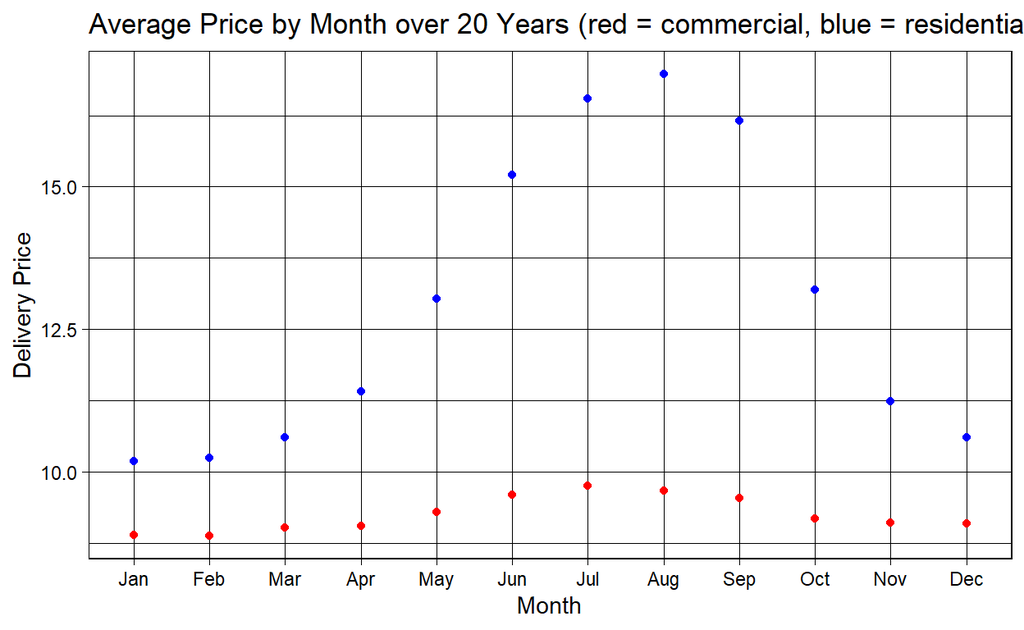

```r
# Globally replace any value that wasn't provided (was a non-numeric), replace it with the median of all the other values in that instance.


ggplot(by_month_summary_data, aes(x = month_data, y = price_res_deliv)) +
  geom_point(aes(y = price_res_deliv, x = month_data), color = "blue")  +
  geom_point(aes(x = month_data, y = price_comm), color="red") +
  theme_linedraw()+
   labs(title="Average Price by Month over 20 Years (red = commercial, blue = residential)", y="Delivery Price", x="Month")
```

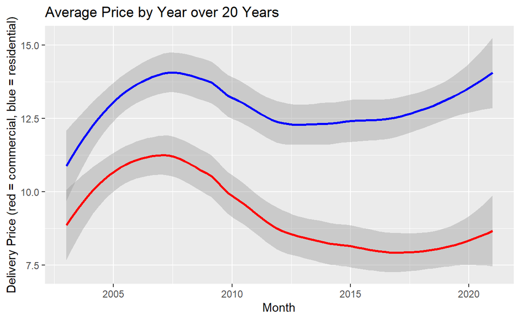

```r
ggplot(by_year_summary_data, aes(x = year_data, y = price_res_deliv)) +
  geom_smooth(aes(y = price_res_deliv, x = year_data), color = "blue")  +
  geom_smooth(aes(x = year_data, y = price_comm), color="red") +
  labs(title="Average Price by Year over 20 Years", y="Delivery Price (red = commercial, blue = residential)", x="Month")
```

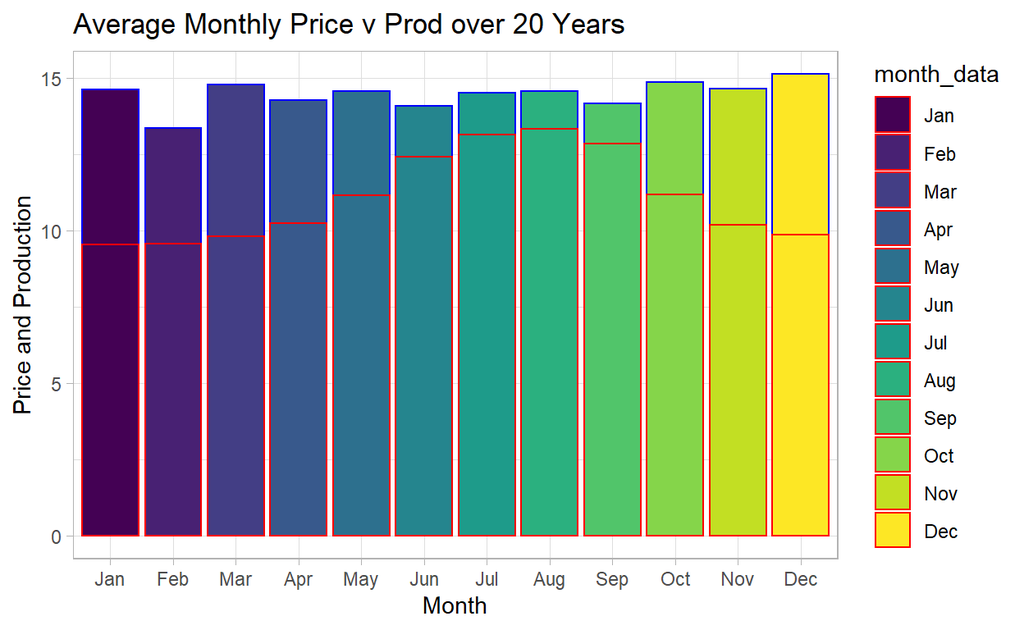

```r
ggplot(by_month_v2_summary_data, aes(x = month_data, y = production_avg, fill = month_data)) +
  geom_col(aes(y = production_avg, x = month_data), color = "blue")  +
  geom_col(aes(x = month_data, y = price), color="red") +
  theme_light() +
  labs(title="Average Monthly Price v Prod over 20 Years", y="Price and Production", x="Month")
```

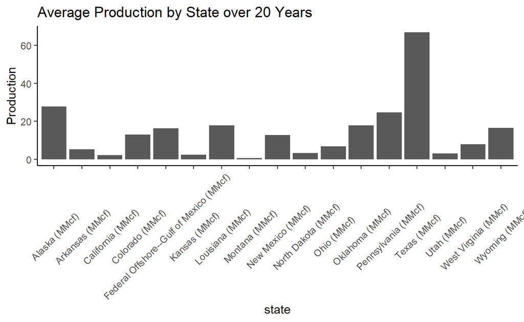

```r
ggplot(by_state_v2_summary_data, aes(x = state, y = production_avg)) +
  geom_col(aes(y = production_avg, x = state))  +
  theme_classic() +
  labs(title="Average Production by State over 20 Years", y="Production") +
  theme(axis.text.x = element_text(angle = 45, vjust = 0.5))
```

```r
# print(by_month_v2_summary_data)

#ggplot(by_month_v2_summary_data, aes(x = month_data, y = production)) +
# geom_smooth(aes(x = month_data, y = price), color="red") +
#  geom_smooth(aes(x = month_data, y = production), color="blue") +
 # facet_wrap(var(month_data)) +
#  labs(title="Average Price by Month over 20 Years", y="Delivery Price", x="Month")


# ggplot(by_month_summary_data, aes(x = month_data)) +
#    geom_line(aes(x = month_data, y = price_res_deliv)) +
#     geom_line(aes(x = month_data, y = price_comm))
```